# 11차 빅데이터 분석 II 및 시각화

## 프로젝트 개요

- 강의명 : (산대특)_공공데이터 활용 빅데이터 분석 및 시각화 전문가 과정 육성
- 교과목명 : 빅데이터 분석 II 및 시각화
- 프로젝트 주제 : tidymodels 라이브러리 및 Sale Price 데이터를 활용한 시각화 및 머신러닝 모델 개발
- 프로젝트 마감일 : 2022년 12월 19일
- 수강생명 : 임여명

## 평가 1. 라이브러리 불러오기 (5점)

- 주요 라이브러리 및 설치 불러오는 코드를 작성한다.

```r
# install.packages('tidymodels')
library(tidymodels)
```

## 평가 2. 데이터 불러오기 (5점)

- Sale_Price 데이터를 불러온다.
- head() 함수를 활용하여 데이터를 개괄적으로 보여주도록 한다.

```r
data("ames")
head(ames)
```

| MS_SubClass | MS_Zoning | Lot_Frontage | Lot_Area | Street | Alley | Lot_Shape | Land_Contour | Utilities | Lot_Config | Land_Slope | Neighborhood | Condition_1 | Condition_2 | Bldg_Type | House_Style | Overall_Cond | Year_Built | Year_Remod_Add | Roof_Style | Roof_Matl | Exterior_1st | Exterior_2nd | Mas_Vnr_Type | Mas_Vnr_Area | Exter_Cond | Foundation | Bsmt_Cond | Bsmt_Exposure | BsmtFin_Type_1 | … |
| --- | --- | --- | --- | --- | --- | --- | --- | --- | --- | --- | --- | --- | --- | --- | --- | --- | --- | --- | --- | --- | --- | --- | --- | --- | --- | --- | --- | --- | --- | --- |
| One_Story_1946_and_Newer_All_Styles | Residential_Low_Density | 141 | 31770 | Pave | No_Alley_Access | Slightly_Irregular | Lvl | AllPub | Corner | Gtl | North_Ames | Norm | Norm | OneFam | One_Story | Average | 1960 | 1960 | Hip | CompShg | BrkFace | Plywood | Stone | 112 | Typical | CBlock | Good | Gd | BLQ | … |
| One_Story_1946_and_Newer_All_Styles | Residential_High_Density | 80 | 11622 | Pave | No_Alley_Access | Regular | Lvl | AllPub | Inside | Gtl | North_Ames | Feedr | Norm | OneFam | One_Story | Above_Average | 1961 | 1961 | Gable | CompShg | VinylSd | VinylSd | None | 0 | Typical | CBlock | Typical | No | Rec | … |
| One_Story_1946_and_Newer_All_Styles | Residential_Low_Density | 81 | 14267 | Pave | No_Alley_Access | Slightly_Irregular | Lvl | AllPub | Corner | Gtl | North_Ames | Norm | Norm | OneFam | One_Story | Above_Average | 1958 | 1958 | Hip | CompShg | Wd Sdng | Wd Sdng | BrkFace | 108 | Typical | CBlock | Typical | No | ALQ | … |
| One_Story_1946_and_Newer_All_Styles | Residential_Low_Density | 93 | 11160 | Pave | No_Alley_Access | Regular | Lvl | AllPub | Corner | Gtl | North_Ames | Norm | Norm | OneFam | One_Story | Average | 1968 | 1968 | Hip | CompShg | BrkFace | BrkFace | None | 0 | Typical | CBlock | Typical | No | ALQ | … |
| Two_Story_1946_and_Newer | Residential_Low_Density | 74 | 13830 | Pave | No_Alley_Access | Slightly_Irregular | Lvl | AllPub | Inside | Gtl | Gilbert | Norm | Norm | OneFam | Two_Story | Average | 1997 | 1998 | Gable | CompShg | VinylSd | VinylSd | None | 0 | Typical | PConc | Typical | No | GLQ | … |
| Two_Story_1946_and_Newer | Residential_Low_Density | 78 | 9978 | Pave | No_Alley_Access | Slightly_Irregular | Lvl | AllPub | Inside | Gtl | Gilbert | Norm | Norm | OneFam | Two_Story | Above_Average | 1998 | 1998 | Gable | CompShg | VinylSd | VinylSd | BrkFace | 20 | Typical | PConc | Typical | No | GLQ | … |

## 평가 3. 데이터 시각화 (50점)

- 시각화 종류에 관계없이 시각화 10개를 작성한다.
- 평가기준
  - 10개 작성 : 50점
  - 7개 작성 : 35점
  - 5개 작성 : 25점
  - 3개 작성 : 15점
- 참고자료
  - URL : http://r-statistics.co/Complete-Ggplot2-Tutorial-Part1-With-R-Code.html

### (1) 산점도그래프

- ames 데이터의 평방 피트 단위의 차고 크기를 기준으로 판매 가격의 Counts산점도 분석
- Sale_Price가 0~200000, Garage_Area가 0~600사이 근처에 산점도가 밀집되어 있다.

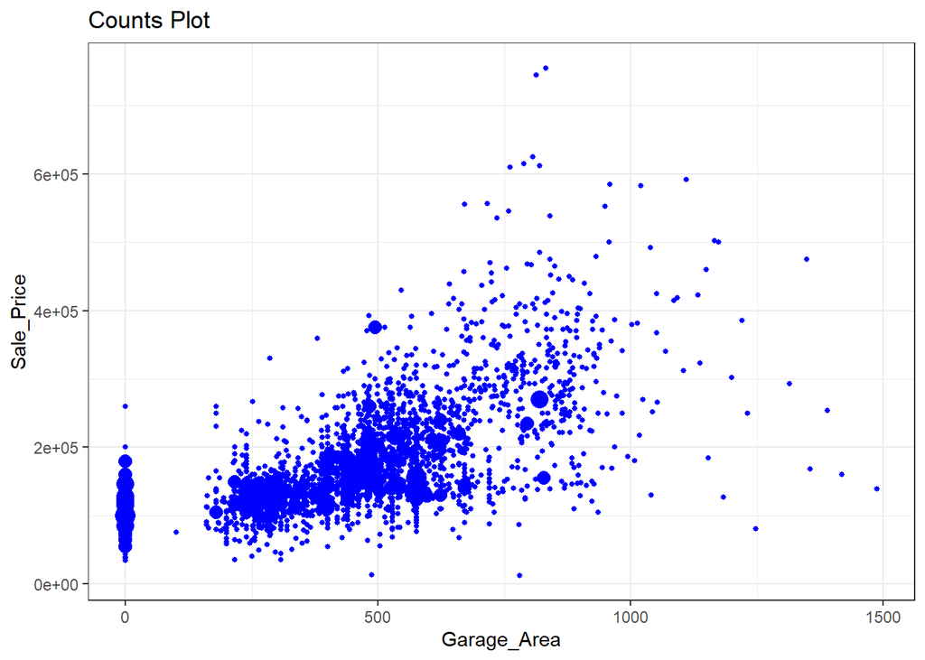

```r
theme_set(theme_bw())
ggplot(ames, aes(x = Garage_Area, y = Sale_Price)) +
geom_count(col="blue", show.legend=F) +
  labs(y="Sale_Price",
       x="Garage_Area",
       title="Counts Plot")
```

### (2) 막대그래프

- ames 데이터의 주거 형태를 기준으로 판매가격을 분석한 막대 그래프
- House_Style에서 One_Story의 Sales_Price가 가장 높은 것으로 분석됨

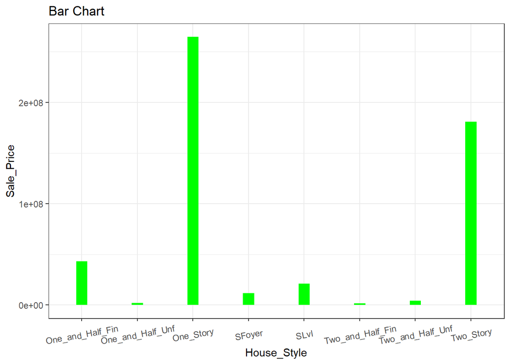

```r
ggplot(ames, aes(x = House_Style , y = Sale_Price)) +
geom_bar(stat="identity", width = 0.2, fill="green") +
      labs(title="Bar Chart"
           ) +
      theme(axis.text.x = element_text(angle=10, vjust=0.5))
```

### (3) 바이올린그래프

- ames 데이터의 판매가격을 기준으로 중앙에어컨 유무를 분석한 Violin plot 그래프
- 30만달러 이상의 고가에 거래된 부동산들은 전부 Central_Air가 Y인 반면 Central_Air가 N인 부동산은 가격이 30만달러 이하임.

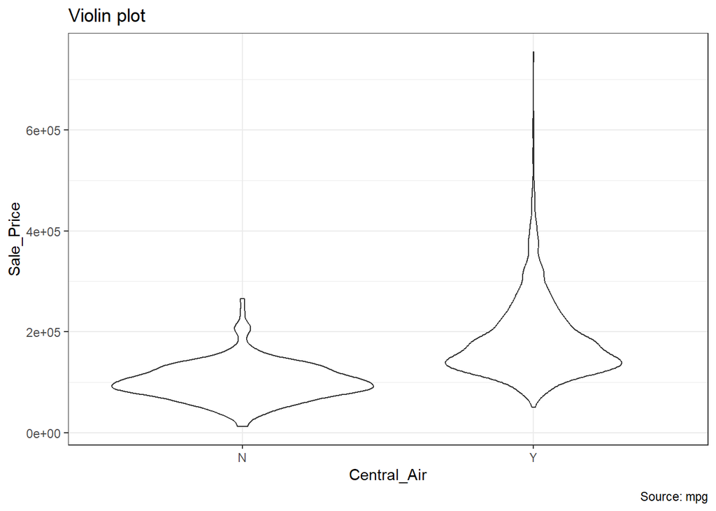

```r
ggplot(ames, aes(Central_Air, Sale_Price)) +
geom_violin() +
labs(title="Violin plot",
       caption="Source: mpg",
       x="Central_Air",
       y="Sale_Price")
```

### (4) 상자그림그래프

- ames 데이터의 판매가격을 기준으로 판매유형의 Box plot을 나타낸 그래프
- Sale_Type에서 WD의 이상점이 넓게 퍼져있는것으로 보아 Sale_Price의 변동이 가장 큰 것을 알 수 있다.

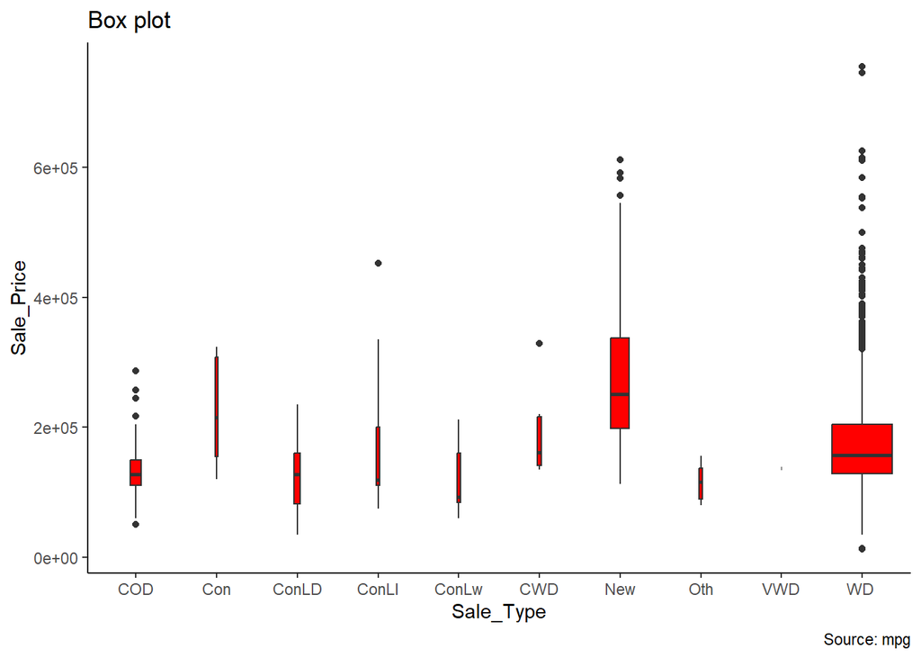

```r
theme_set(theme_classic())
ggplot(ames, aes(Sale_Type, Sale_Price)) +
geom_boxplot(varwidth=T, fill="red") +
    labs(title="Box plot",
         caption="Source: mpg",
         x="Sale_Type",
         y="Sale_Price")
```

### (5) 히스토그램

- ames 데이터의 판매 유형을 기준으로 판매횟수와 판매가격을 분석한 히스토그램
- 가장 많이 판매된 Sale_Type은 20만달러 이하 가격의 WD으로 분석됨

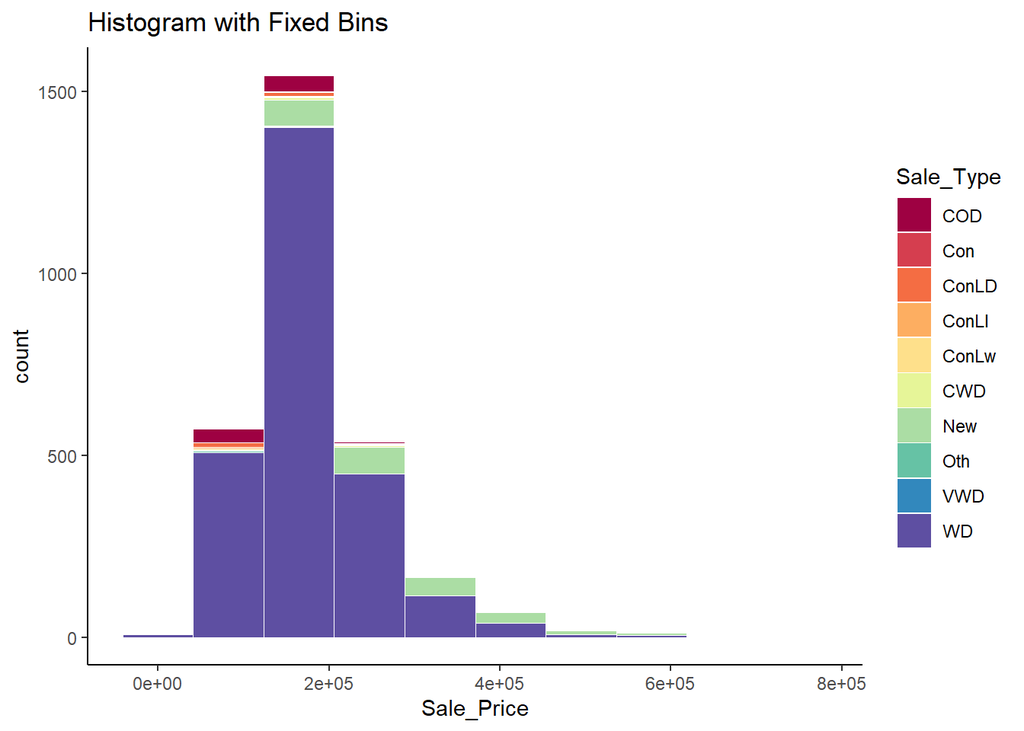

```r
ggplot(ames, aes(Sale_Price)) + scale_fill_brewer(palette = "Spectral") +
geom_histogram(aes(fill=Sale_Type),
                   bins=10,
                   col="white",
                   size=.1) +
  labs(title="Histogram with Fixed Bins")
```

## 평가 4. 요약 통계 구하기 (10점)

- Sale_Price가 500000 이상인 데이터 중에서 Pool_QC에 따른 평균 Sale_Price 값을 구한다.

```r
ames %>%
  filter(Sale_Price >= 500000) %>%
  group_by(Pool_QC) %>%
  summarize(avg_price = mean(Sale_Price))
```

| Pool_QC | avg_price |
| --- | --- |
| Excellent | 680000.0 |
| No_Pool | 571524.1 |

## 평가 5. 머신러닝 모델링 (20점)

- 주어진 규칙에 따라 머신러닝 코드를 작성한다.
  - `8:2` 비율로 훈련데이터셋 및 테스트데이터셋으로 분리한다. (5점)
  - 모델링은 `RandomForest`와 `glmnet` 알고리즘을 활용한다. (10점)
    - 만약 1개만 사용 시 5점만 부여
  - feature Engineering 코드는 주어진 코드이기 때문에 그대로 활용한다.
- 옵션: 필요 시, 라이브러리 설치를 한다.
  - `install.packages(c('ranger', 'glmnet'))`
- Sale_Price와 각 모델의 예측 결과표를 만든다. (5점)

### (1) 훈련/테스트 데이터셋 만들기

- `8:2` 비율로 훈련데이터셋 및 테스트데이터셋으로 분리한다. (5점)

```r
set.seed(42)

ames_split = initial_split(ames, strata = 'Sale_Price', prop = 0.8)

ames_train = training(ames_split)
ames_test = testing(ames_split)

# 다음 코드는 예시다
normal_recipe = recipe(
    Sale_Price ~ Longitude + Latitude + Lot_Area + Neighborhood + Year_Sold,
    data = ames_train
  ) %>%
  step_other(Neighborhood) %>%
  step_dummy(all_nominal()) %>%
  step_center(all_predictors()) %>%
  step_scale(all_predictors()) %>%
  step_log(Sale_Price, base = 10) %>%

  prep(training = ames_train, retain = TRUE)

norm_test = bake(normal_recipe, new_data = ames_test, all_predictors())
```

### (2) RandomForest

- RandomForest 모형을 작성 후, 확인한다.

```r
# Random Forest
rf_fit = rand_forest(mode = "regression", mtry = .preds(), trees = 2000) %>%
  set_engine("ranger") %>%
  fit(
    Sale_Price ~ ., data = bake(normal_recipe, new_data = NULL)
  )

rf_fit
```

```
## parsnip model object
##
## Ranger result
##
## Call:
##  ranger::ranger(x = maybe_data_frame(x), y = y, mtry = min_cols(~.preds(),      x), num.trees = ~2000, num.threads = 1, verbose = FALSE,      seed = sample.int(10^5, 1))
##
## Type:                             Regression
## Number of trees:                  2000
## Sample size:                      2342
## Number of independent variables:  12
## Mtry:                             12
## Target node size:                 5
## Variable importance mode:         none
## Splitrule:                        variance
## OOB prediction error (MSE):       0.009227299
## R squared (OOB):                  0.7113394
```

### (3) glmnet

- glmnet 모형을 작성 후, 확인한다.

```r
# glmnet
GLM = linear_reg(penalty = 0.001, mixture = 0.5) %>%
  set_engine("glmnet") %>%
  fit(Sale_Price ~ ., data = bake(normal_recipe, new_data = NULL))

GLM
```

```
## parsnip model object
##
##
## Call:  glmnet::glmnet(x = maybe_matrix(x), y = y, family = "gaussian",      alpha = ~0.5)
##
##    Df  %Dev   Lambda
## 1   0  0.00 0.133700
## 2   1  1.79 0.121800
## 3   1  3.39 0.111000
## 4   2  4.82 0.101200
## 5   2  6.99 0.092170
## 6   4  9.67 0.083980
## 7   5 12.63 0.076520
## 8   5 15.31 0.069720
## 9   7 18.35 0.063530
```

[output cut: 56 more lines]

### (4) 예측 결과표 만들기

- Sale_Price 컬럼과 예측 모델 결과표를 합한 새로운 데이터 프레임이다.

```r
norm_test = bake(normal_recipe, new_data = ames_test, all_predictors())

result = ames_test  %>%
  select(Sale_Price) %>%
  mutate(Sale_Price = log10(Sale_Price)) %>%
  bind_cols(
    predict(rf_fit, new_data = norm_test) %>%
      rename(randomForest = .pred)
    , predict(GLM, new_data = norm_test) %>%
      rename(glmnet = .pred)
  )

result
```

| Sale_Price | randomForest | glmnet |
| --- | --- | --- |
| 5.021189 | 5.242486 | 5.171412 |
| 5.235528 | 5.306325 | 5.182510 |
| 5.595972 | 5.489733 | 5.246410 |
| 5.152288 | 5.182369 | 5.176873 |
| 5.264818 | 5.147972 | 5.156628 |
| 4.982271 | 5.022213 | 5.188006 |
| 5.023252 | 5.028640 | 5.188280 |
| 4.944483 | 4.998038 | 5.187802 |
| 5.175802 | 5.123064 | 5.186578 |
| 5.698970 | 5.639099 | 5.494067 |

[output cut: 578 more lines]

## 평가 6. 두개의 모형 비교 (10점)

- 회귀모형 평가지표를 활용하여 예측 지표를 작성한다. (5점)

```r
random_result = result %>%
  metrics(truth = Sale_Price, estimate = randomForest) %>%
  mutate(model = 'randomForest')

GLM_result = result %>%
  metrics(truth = Sale_Price, estimate = glmnet) %>%
  mutate(model = 'glmnet')

bind_rows(random_result, GLM_result)
```

| .metric | .estimator | .estimate | model |
| --- | --- | --- | --- |
| rmse | standard | 0.08607090 | randomForest |
| rsq | standard | 0.74760828 | randomForest |
| mae | standard | 0.06469912 | randomForest |
| rmse | standard | 0.12822174 | glmnet |
| rsq | standard | 0.43477287 | glmnet |
| mae | standard | 0.09538300 | glmnet |

- 두개의 그래프를 비교하는 코드를 작성한다. (5점)

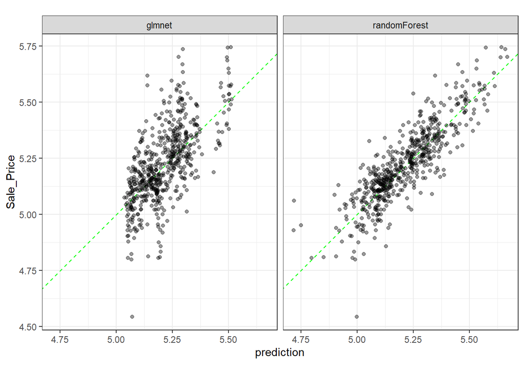

```r
result %>%
  gather(model, prediction, -Sale_Price) %>%
  ggplot(aes(x = prediction, y = Sale_Price)) +
  geom_abline(col = "green", lty = 2) +
  geom_point(alpha = .4) +
  facet_wrap(~model) +
  coord_fixed() +
  theme_bw()
```

.